# GpPlot homework

## Question 1.

Load the libraries: CodeClan Data & tidyverse

```r
library(tidyverse)
library(CodeClanData)
```

Look at the `backpack` data, get variable names & dimension of the dataset.

```r
names(backpack)
```

```
[1] "backpack_weight" "body_weight"     "ratio"           "back_problems"
[5] "major"           "year"            "sex"             "status"
[9] "units"
```

```r
dim(backpack)
```

```
[1] 100   9
```

```r
backpack
```

| backpack_weight | body_weight | ratio | back_problems | major | year | sex | status | units |
| --- | --- | --- | --- | --- | --- | --- | --- | --- |
| 9 | 125 | 0.0720000 | 1 | Bio | 3 | Female | U | 13 |
| 8 | 195 | 0.0410256 | 0 | Philosophy | 5 | Male | U | 12 |
| 10 | 120 | 0.0833333 | 1 | GRC | 4 | Female | U | 14 |
| 6 | 155 | 0.0387097 | 0 | CSC | 6 | Male | G | 0 |
| 8 | 180 | 0.0444444 | 0 | EE | 2 | Female | U | 14 |
| 5 | 240 | 0.0208333 | 0 | History | 0 | Male | G | 0 |
| 8 | 170 | 0.0470588 | 0 | CM | 3 | Male | U | 15 |
| 4 | 185 | 0.0216216 | 1 | ARCE | 5 | Female | U | 18 |
| 5 | 130 | 0.0384615 | 0 | Bio | 4 | Female | U | 14 |
| 2 | 120 | 0.0166667 | 0 | Bio | 5 | Female | U | 8 |

[output cut: 90 more lines]

## Question 2.

What is the distribution of the of backpack wights that students carry.

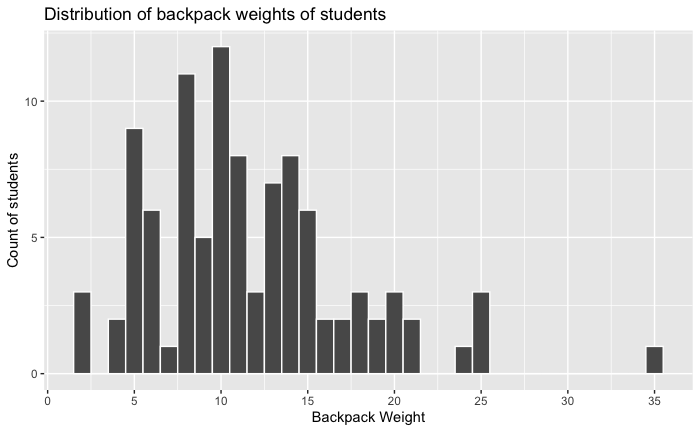

```r
ggplot(backpack) +
  aes(x = backpack_weight) +
  geom_histogram(col = "white", binwidth = 1) +
  labs(title = "Distribution of backpack weights of students",
       x = "Backpack Weight",
       y = "Count of students") +
  scale_y_continuous(breaks = c(0,5,10,15))+
  scale_x_continuous(breaks = c(0,5,10,15,20,25,30,35))
```

## Question 3.

Are there differences in backpack weight between sex?

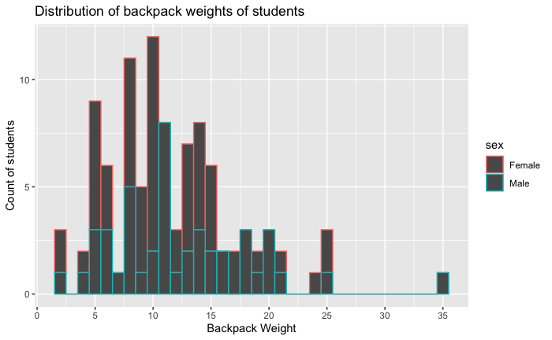

```r
#overlay two histograms
ggplot(backpack) +
  aes(x = backpack_weight, colour = sex) +
  geom_histogram(binwidth = 1)+
  labs(title = "Distribution of backpack weights of students",
       x = "Backpack Weight",
       y = "Count of students") +
  scale_y_continuous(breaks = c(0,5,10,15)) +
  scale_x_continuous(breaks = c(0,5,10,15,20,25,30,35))
```

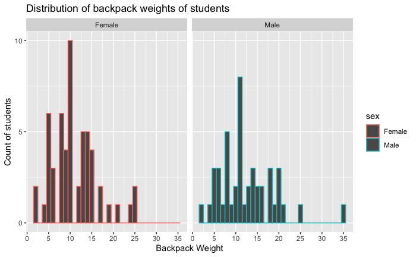

```r
#faceted by sex
ggplot(backpack) +
  aes(x = backpack_weight, colour = sex) +
  geom_histogram(binwidth = 1)+
  labs(title = "Distribution of backpack weights of students",
       x = "Backpack Weight",
       y = "Count of students") +
  scale_y_continuous(breaks = c(0,5,10,15))+
  scale_x_continuous(breaks = c(0,5,10,15,20,25,30,35)) +
  facet_wrap(~ sex, ncol = 2)
```

I found that it was easier to see details on the faceted chart.

From the chart it looks like male students tend to carry heavier backpacks than female students.

## Question 4.

What is the relationship between body weight and backpack weight?

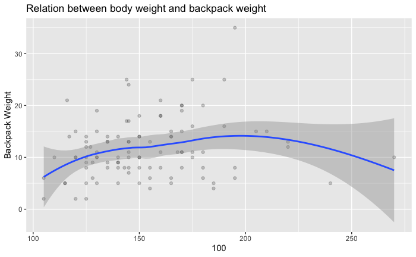

```r
ggplot(backpack) +
  aes(x = body_weight, y = backpack_weight) +
  labs(title = "Relation between body weight and backpack weight",
       x = "Body Weight",
       y = "Backpack Weight") +
  scale_x_continuous(c(100:300)) +
  geom_point(alpha = 0.2) +
  geom_smooth()
```

It looks like students whos weight is up to 150 tend to have slightly lighter backpacks than students whos weight is between 150 and 200. It seems like students whos weight is over 200 tend to have lighter backpacks, however our analysis of this group of students is prone to errors, because we do not have many data points.

## Question 5.

Is this relationship (boduweight and backpack) different between men and women? Choose an appropriate plot and interpret your findings.

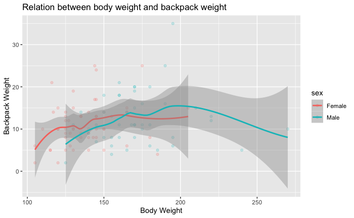

```r
ggplot(backpack) +
  aes(x = body_weight, y = backpack_weight, colour = sex) +
  labs(title = "Relation between body weight and backpack weight",
       x = "Body Weight",
       y = "Backpack Weight") +
  geom_point(alpha = 0.2) +
  geom_smooth() #+
```

```r
  #facet_wrap(~ sex, ncol = 2)
```

## Question 6.

What proportion of students report back pain?

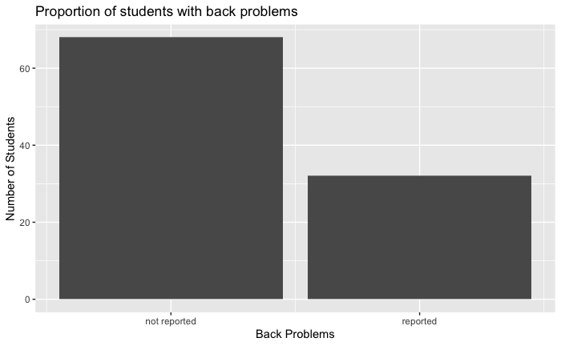

```r
proportion_back_problems <- backpack %>%
  count(back_problems) %>%
  mutate(back_problems = (ifelse(back_problems == 0, "not reported", "reported")), proportion_of_students = n/4)

ggplot(backpack) +
  geom_bar(aes(x = back_problems), stat = "count") +
  labs(title = "Proportion of students with back problems",
       x = "Back Problems",
       y = "Number of Students") +
  scale_x_continuous(breaks = c(0, 1),
                     labels = c("0" = "not reported",
                                "1" = "reported"))
```

```r
proportion_back_problems
```

| back_problems | n | proportion_of_students |
| --- | --- | --- |
| not reported | 68 | 17 |
| reported | 32 | 8 |

Most students have not reported any back problems. In fact, a total of 68 students have reported no back problems and 32 students have reported back problems. Which is a ratio of 17:8.

# Question 7.

Is this proportion different between men and women?

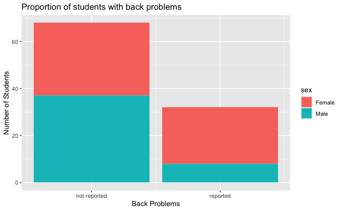

```r
ggplot(backpack) +
  geom_bar(aes(x = back_problems, fill = sex), stat = "count") +
  labs(title = "Proportion of students with back problems",
       x = "Back Problems",
       y = "Number of Students") +
  scale_x_continuous(breaks = c(0, 1),
                     labels = c("0" = "not reported",
                                "1" = "reported"))
```

```r
proportion_back_problems_by_sex <- backpack %>%
  group_by(sex) %>%
  count(back_problems) %>%
  mutate(back_problems = (ifelse(back_problems == 0, "not reported", "reported")))

proportion_back_problems_by_sex
```

| sex | back_problems | n |
| --- | --- | --- |
| Female | not reported | 31 |
| Female | reported | 24 |
| Male | not reported | 37 |
| Male | reported | 8 |

If we split our back pain data by sex, we can see that of those students who have not reported any back problems, the split is quite even between female and male students. The ratio is 31:37)

But of those students who did report back poblems, the numbrer of female students is considerably higher. The ratio is (24:8) or 3:1

# Question 8.

Create plots to describe the relationship between backpack weight, body weight, gender and reported backpain.

```r
ggplot(backpack) +
  geom_bar(aes(x = backpack_weight, y = ratio))
```

```
Error: stat_count() can only have an x or y aesthetic.
```